# Treasure Coast - FDOT Crosswalk Demand Approach

Renaissance Planning / Joel Lehman

# FDOT Demand / Crash / Bus / Income Analysis

## Overview

The following maps identify roadway segments that meet FDOT mid-block demand criteria as outlined in the [Guidelines for Installing Pedestrian Treatments at Midblock Locations (2020)](https://fdotwww.blob.core.windows.net/sitefinity/docs/default-source/research/reports/fdot-bdv29-977-49-rpt.pdf?sfvrsn=4bb50c39_4).

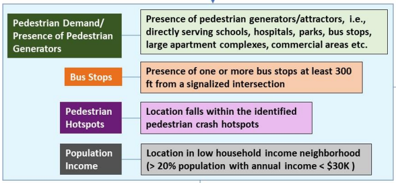

## Data & Method

### Method

Analysis segments, split at 500 feet max lengths, are buffered by 1/8 mile. Land use and transportation characteristics data are summarized within this buffer based on a logical yes/no per category. Note that household income is summarized to 1/4-mile buffers, due to Census ACS precision.

### Data

- [Florida Statewide Land Cover Land Use](https://geodata.dep.state.fl.us/datasets/statewide-land-use-land-cover/explore)
  - Recreation & Education Facilities in the following categories:
    - Parks and Zoos
    - Community Recreational Facilities
    - Educational Facilities")
  - Residential High Density
  - Commercial and Services
- FDOT Basemap (segments split)
- Census ACS (2019 5-year estimates) - Household Income
- Transit stops (points)

Per the FDOT report, no crash hotspots are in the study corridor, so this data was not analyized.

### Land Use Layer

The following map displays the land use input used in this analysis, which is used to estimate the presence of Pedestrian Demand / Presence of Pedestrian Generators

[interactive chart not shown]

## Analysis Results

This map shows the presence of any one of the four factors mentioned in the FDOT report.

### Final Map - Presence of any FDOT Flag

[interactive chart not shown]